# Supplementary File

2023-04-24

# A Multilevel Mediation Analysis of Area-Level Poverty and CA-MRSA Infection Rates Across California Communities

This paper will use the product and different method (traditional approaches to mediation analysis) for regressions with a binary outcome as outlined by VanderWeele, 2016 (https://www.annualreviews.org/www.annualreviews.org/doi/full/10.1146/annurev-publhealth-032315-021402#_i21) implemented in R-INLA to account for spatial dependency.

The main hypothesis is that area-level poverty is associated with CA-MRSA presenting in rural MSSAs ED and can be mediated or explained through other area-level predictors. The outcome is observed at the individual level, and we have information available at a higher level of aggregation (MSSA) (2-2-1 mediation analysis)

This paper’s *objectives* are as follows:

1. Fit a Bayesian multilevel model with area-level as the main covariate where the outcome is observed at the individual level
2. Evaluate the influence of three potential mediators by including group-level covariates
3. Examine the influence of spatial autocorrelation

*The population denominator for the MSSA-level covariates is from the 2019 American Community* *Survey Estimates*

```r
library(tidyverse)
library(dplyr)
library(sf) # spatial data
library(tmap) # spatial mapping
library(spdep)
library(ggplot2)
library(RColorBrewer)
library(expss) # summary statistic tables
library(INLA) # multilevel spatial regression modeling
library(brinla) # bayesian regression with inla book
library(car)
library(tidygeocoder) # geocode prison locations


load(file = "/Users/brittanymorgan/Desktop/Data/df.full")
```

## **2. Data Wrangling**

#### Under-sampling the non-cases to create more balance in the dataset (9:100 sampling), but still remain under the 10% threshold for using logistic regression

```r
# remove individuals in Avalon MSSA from the analysis (has no neighbors and is an island)
df.full <- df.full %>%
  filter(mssa != "Avalon") #232 cases removed (5,056 observations)

# filter cases
cases <- df.full %>%
  filter(ssti == 1)

# filter non-cases
noncases <- df.full %>%
  filter(ssti == 0)

remove(df.full)
```

```r
# pull all cases
set.seed(99011)
c <- setNames(replicate(2, sample(1:nrow(cases), 844564,
                                  replace = FALSE), simplify = FALSE), 1:2)
cs = lapply(seq_along(c), function(i) transform(cases[c[[i]], ], ind = i))
csamp <- do.call(rbind, cs)

# random sample noncases
set.seed(99012)
nc <- setNames(replicate(2, sample(1:nrow(noncases), 8539480,
                                    replace = TRUE), simplify = FALSE), 1:2)
ncs = lapply(seq_along(nc), function(i) transform(noncases[nc[[i]], ], ind = i))
ncsamp <- do.call(rbind, ncs)

sampled_df <- rbind(csamp, ncsamp)

remove(c, cases, cs, csamp, nc, ncs, ncsamp, noncases)
```

#### Recode individual-level variables

```r
# outcome (ssti)
sampled_df$y <- ifelse(sampled_df$ssti == 1, 1, 0)

# sex, female as reference
sampled_df$sexcat <- car::Recode(sampled_df$sex, recodes = "'M' = 'male';
                                                 'F' = 'female';
                                                  else = NA", as.factor = T)
sampled_df$sexcat <- relevel(sampled_df$sexcat, ref = "female")

# race/ethnicity
sampled_df$race_eth <- car::Recode(sampled_df$racegrp, recodes = "'NH-White' = 'nhwhite';
                                                            'NH-Black' = 'nhblack';
                                                            'NH-Asian' = 'nhapi';
                                                            'NH-Islander' = 'nhapi';
                                                            'Hispanic' = 'hispanic';
                                                            'NH-AIAN' = 'other';
                                                            'Other' = 'other';
                                                            else = NA", as.factor = T)
sampled_df$race_eth <- relevel(sampled_df$race_eth, ref = "nhwhite")

# insurance, private as reference
sampled_df$insurance <- car::Recode(sampled_df$insure, recodes = "'private' = 'private';
                                                           'public' = 'public';
                                                           'uninsured' = 'uninsured';
                                                           else = NA", as.factor = T)
sampled_df$insurance <- relevel(sampled_df$insurance, ref = "private")

# age category, 65 and over as reference
sampled_df$agec <- car::Recode(sampled_df$agecat, recodes = "'18-34' = '18-34';
                                                      '35-64' = '35-64';
                                                      '65+' = '65 and over';
                                                      else = NA", as.factor = T)
sampled_df$agec <- relevel(sampled_df$agec, ref = "65 and over")
```

#### Recode MSSA-level variables

Prison df comes from the Census of State and Federal Adult Correctional Facilities, 2019 by the US Bureau of Justice Statistics: https://www.icpsr.umich.edu/web/ICPSR/studies/38325/variables?start=50&STUDYQ=38325&EXTERNAL_FLAG=1&ARCHIVE=ICPSR&sort=VARLABEL_SORT%20asc&rows=50 *(accessed and downloaded on February 3, 2023)*

```r
load(file = "/Users/brittanymorgan/Desktop/Data/mssa.df")
hcsa <- read.csv(file = "/Users/brittanymorgan/Desktop/Data/Health_Professional_Shortage_Area_Primary_Care.csv") # for adding healthcare shortage areas
prisons <- read.csv("/Users/brittanymorgan/Desktop/Data/CA prisons.csv") # for identifying areas with a prison

# geocode prison df
prison_geocode <- prisons %>%
  geocode_combine(queries = list(
    list(method = "census",
         mode = "batch",
         street = "V006_2",
         city = "V007",
         state = "V008",
         postalcode = "V010"),
    list(method = "census",
         mode = "single",
         street = "V006_2",
         city = "V007",
         state = "V008",
         postalcode = "V010"),
    list(method = "osm",
         address = "Address"),
    list(method = "arcgis",
         address = "Address")))
```

```
## Passing 42 addresses to the US Census batch geocoder
```

```
## Query completed in: 1.7 seconds
```

```
## Passing 10 addresses to the US Census single address geocoder
```

```
## Query completed in: 2.2 seconds
```

```
## Passing 10 addresses to the Nominatim single address geocoder
```

[output not shown]

[output not shown]

```
## Query completed in: 20.3 seconds
```

```
## Passing 5 addresses to the ArcGIS single address geocoder
```

```
## Query completed in: 2.7 seconds
```

```r
ca_prisons <- prison_geocode %>%
  dplyr::mutate(prison = 1) %>%
  dplyr::select(V005, prison, lat, long)

ca_prisons_sf <- ca_prisons %>%
                 st_as_sf(coords = c("long", "lat"),
                          crs = "+proj=longlat +datum=WGS84 +ellps=WGS84")

st_crs(mssa.df) == st_crs(ca_prisons_sf) # need to reproject mssa df
```

```
## [1] TRUE
```

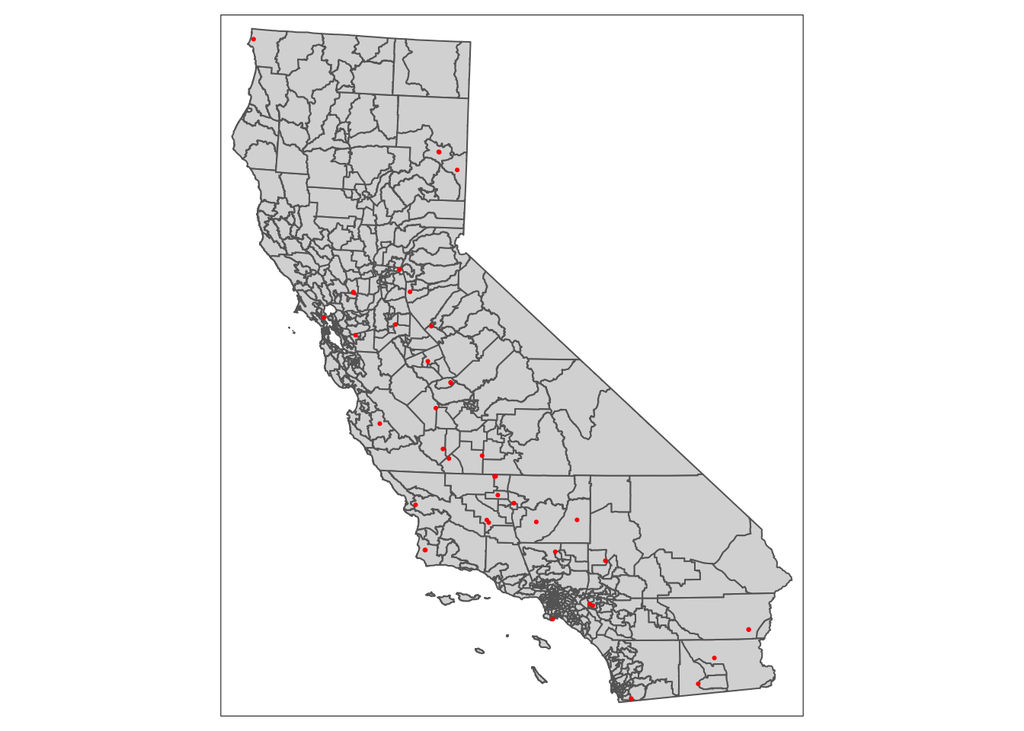

```r
mssa.utm <- mssa.df %>%
              st_transform(crs = "+proj=utm +zone=11 +datum=NAD83 +ellps=GRS80")
prisons.utm <-ca_prisons_sf %>%
              st_transform(crs = "+proj=utm +zone=11 +datum=NAD83 +ellps=GRS80")

# plot prisons on a map
tm_shape(mssa.utm) +
  tm_polygons() +
tm_shape(prisons.utm) +
  tm_dots(col = "red")
```

```r
# sum prisons in each MSSA
prisons_agg <- aggregate(prisons.utm["V005"], mssa.utm, FUN = "length")
mssa.prisons <- prisons_agg %>%
  mutate(prison = V005,
         prison = replace_na(prison, 0)) %>%
  st_join(mssa.utm, join = st_within, left = FALSE)

remove(prisons, prisons_agg, prisons.utm, mssa.utm, prison_geocode, ca_prisons, ca_prisons_sf,
       mssa.df)

# health care shortage area indicator
hcsa$hcsa <- 1
hcsa.flag <- hcsa %>%
  dplyr::select(mssa = MSSA_NAME, hcsa)

mssa <- left_join(mssa.prisons, hcsa.flag, by = c("mssa" = "mssa")) %>%
  mutate(hcsa = if_else(is.na(hcsa), 0, hcsa))

# prison in mssa (yes/no)
mssa$prisonflag <- ifelse(mssa$prison != 0, 1, 0)

# frontier/rural location
mssa$ruralflag <- ifelse(mssa$rural == "Urban or Town", 0, 1)

# poverty category, using distribution
cuts = quantile(mssa$pctpov, c(0, 1/4, 2/4, 3/4, 1))

# scale poverty rate (continuous)
mssa$povertyz <- scale(mssa$pctpov)

# scale percent crowded
mssa$crowdz <- scale(mssa$pctcrowd)

# Enviroscreen score category, using distribution
cuts2 = quantile(mssa$avgscore, c(0, 1/4, 2/4, 3/4, 1), na.rm = TRUE)
mssa <- mssa %>%
        mutate(pollution = cut(avgscore, breaks = cuts2,
                             labels = c("Q1", "Q2", "Q3", "Q4"), include.lowest = TRUE),
               poverty = cut(pctpov, breaks = cuts,
                             labels = c("Q1", "Q2", "Q3", "Q4"), include.lowest = TRUE))
# boxplot(mssa$avgscore ~ mssa$pollution, col = 3:6)
# boxplot(mssa$pctpov ~ mssa$poverty, col = 3:6)

# scale average EnviroScreen score (continuous)
mssa$avgscorez <- scale(mssa$avgscore)

remove(hcsa, hcsa.flag, mssa.prisons)
```

## **2. Data Exploration**

#### Summary Statistics for individual level data in data frame

```r
# SSTI by male sex
cross_cases(sampled_df, sexcat, ind, y)
```

|  |  |  |  | ind 1 | ind 2 |
| --- | --- | --- | --- | --- | --- |
| y |  |  |  |  |  |
| 0 | sexcat | female |  | 4903038 | 4903324 |
|  |  | male |  | 3636036 | 3635734 |
|  |  | #Total cases |  | 8539074 | 8539058 |
| 1 | sexcat | female |  | 379256 | 379256 |
|  |  | male |  | 465269 | 465269 |
|  |  | #Total cases |  | 844525 | 844525 |

```r
# SSTI by race/ethnicity
cross_cases(sampled_df, race_eth, ind, y)
```

|  |  |  |  | ind 1 | ind 2 |
| --- | --- | --- | --- | --- | --- |
| y |  |  |  |  |  |
| 0 | race_eth | nhwhite |  | 3378830 | 3380722 |
|  |  | hispanic |  | 3112928 | 3112980 |
|  |  | nhapi |  | 803409 | 805619 |
|  |  | nhblack |  | 996649 | 993344 |
|  |  | other |  | 39572 | 39662 |
|  |  | #Total cases |  | 8331388 | 8332327 |
| 1 | race_eth | nhwhite |  | 390343 | 390343 |
|  |  | hispanic |  | 286199 | 286199 |
|  |  | nhapi |  | 57077 | 57077 |
|  |  | nhblack |  | 87433 | 87433 |
|  |  | other |  | 5195 | 5195 |
|  |  | #Total cases |  | 826247 | 826247 |

```r
# SSTI by insurance status
cross_cases(sampled_df, insurance, ind, y)
```

|  |  |  |  | ind 1 | ind 2 |
| --- | --- | --- | --- | --- | --- |
| y |  |  |  |  |  |
| 0 | insurance | private |  | 2387008 | 2388640 |
|  |  | public |  | 5514371 | 5512981 |
|  |  | uninsured |  | 625095 | 625217 |
|  |  | #Total cases |  | 8526474 | 8526838 |
| 1 | insurance | private |  | 191318 | 191318 |
|  |  | public |  | 575389 | 575389 |
|  |  | uninsured |  | 77518 | 77518 |
|  |  | #Total cases |  | 844225 | 844225 |

```r
# SSTI by age
cross_cases(sampled_df, agec, ind, y)
```

|  |  |  |  | ind 1 | ind 2 |
| --- | --- | --- | --- | --- | --- |
| y |  |  |  |  |  |
| 0 | agec | 65 and over |  | 1771698 | 1771314 |
|  |  | 18-34 |  | 2902901 | 2903445 |
|  |  | 35-64 |  | 3864881 | 3864721 |
|  |  | #Total cases |  | 8539480 | 8539480 |
| 1 | agec | 65 and over |  | 126601 | 126601 |
|  |  | 18-34 |  | 277254 | 277254 |
|  |  | 35-64 |  | 440709 | 440709 |
|  |  | #Total cases |  | 844564 | 844564 |

#### Area-Level Variable Distributions

*Check distribution of area-level poverty*

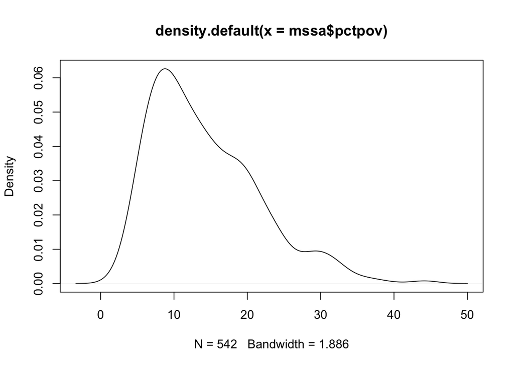

```r
den_pov <- density(mssa$pctpov)
plot(den_pov)
```

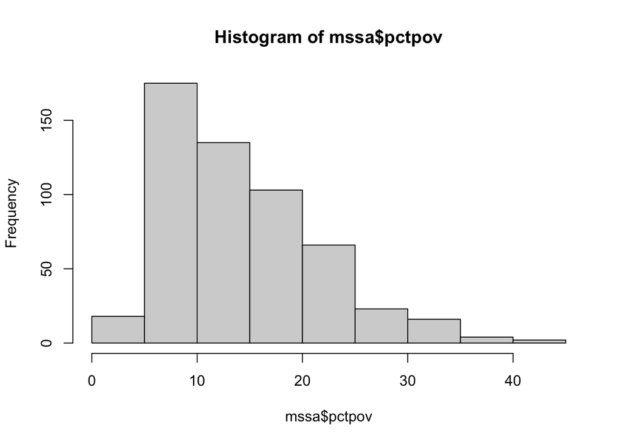

```r
hist(mssa$pctpov)
```

*Check distribution of environmental degradation score*

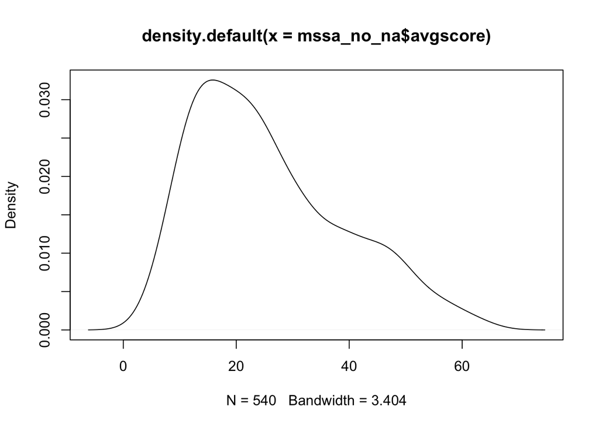

```r
mssa_no_na <- mssa %>%
              dplyr::select(mssa, avgscore) %>%
              na.omit()
den_score <- density(mssa_no_na$avgscore)
plot(den_score)
```

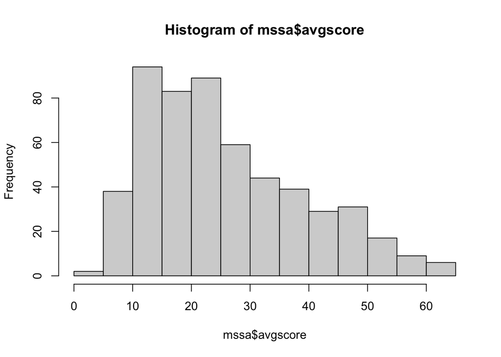

```r
hist(mssa$avgscore)
```

*Percent under 100% Federal Poverty Limit*

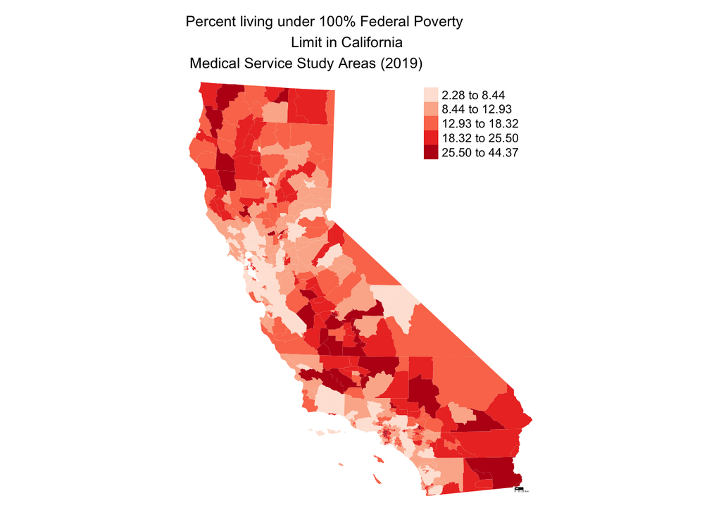

```r
# percent under 100% FPL
tm_shape(mssa) +
  tm_polygons(col = "pctpov", style = "jenks", border.alpha = 0,
              title = "", palette = "Reds") +
  tm_scale_bar(breaks = c(0, 10, 20), text.size = 1) +
  tm_layout(main.title = "Percent living under 100% Federal Poverty
                          Limit in California \n Medical Service Study Areas (2019)",
            main.title.size = 0.85, frame = FALSE)
```

*Percent Crowding*  
ACS defines crowding as more than 1 person per bedroom in homes/apartments that are rented or owned

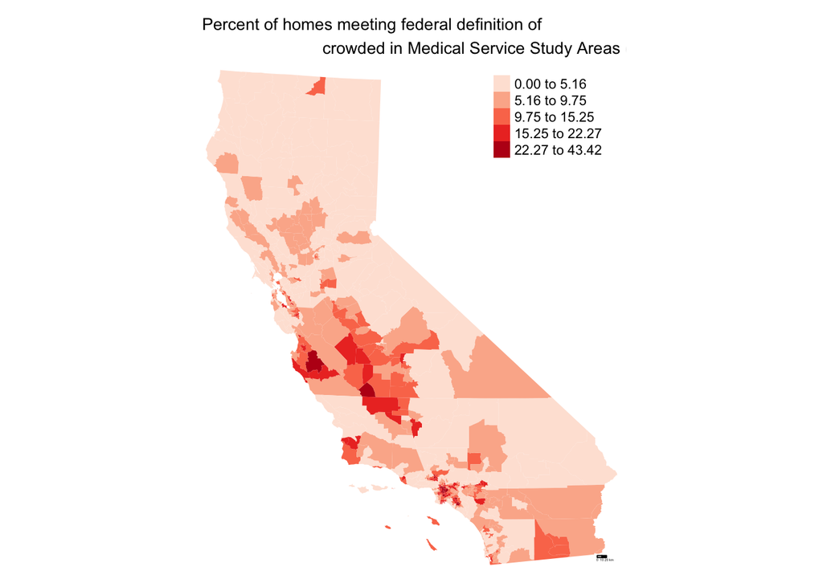

```r
# percent crowding
tm_shape(mssa) +
  tm_polygons(col = "pctcrowd", style = "jenks", border.alpha = 0, palette = "Reds",
              title = "") +
  tm_scale_bar(breaks = c(0, 10, 20), text.size = 1) +
  tm_layout(main.title = "Percent of homes meeting federal definition of
                          crowded in Medical Service Study Areas (2019)",
            main.title.size = 0.85, frame = FALSE)
```

*Primary health care shortage areas (HCSA)*  
HCSAs are designated by Health Resources and Services Administration (HRSA) as having a shortage of primary care providers. Shortage is defined as a population to primary care physician ratio of 3,500:1 or 3,000:1 if the population demonstrates “unusually high need”

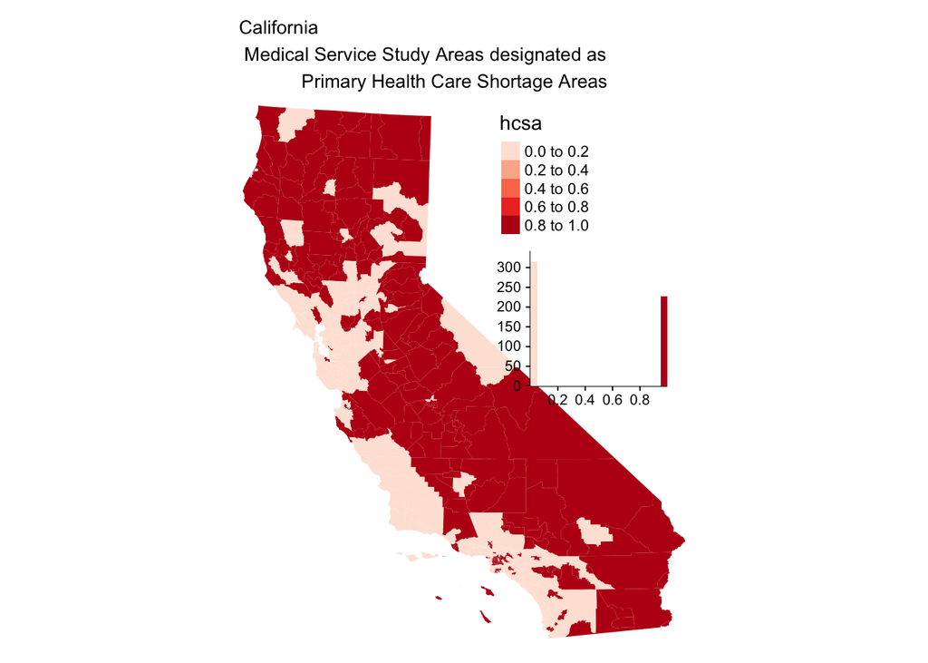

```r
# primary health care shortage areas
tm_shape(mssa) +
  tm_polygons(col = "hcsa", palette = "Reds", lwd = 1, border.alpha = 0,
              legend.hist = TRUE) +
  tm_layout(main.title = "California \n Medical Service Study Areas designated as
            Primary Health Care Shortage Areas",
            main.title.size = 0.85, frame = FALSE)
```

*Rural/Urban Classification*  
HCAi defines rural as a population density of less than 250 people per square mile and having no census defined area with more than 50,000 people.

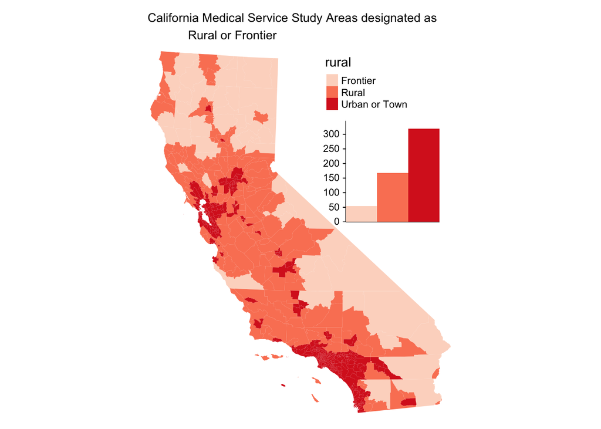

```r
# rural/urban
tm_shape(mssa) +
  tm_polygons(col = "rural", palette = "Reds", lwd = 1, border.alpha = 0,
              legend.hist = TRUE) +
  tm_layout(main.title = "California Medical Service Study Areas designated as
            Rural or Frontier",
            main.title.size = 0.85, frame = FALSE)
```

*Average CalEnviroScreen 4.0 Score*  
CalEnviroScreen score is calculated at the census tract level. Previous studies have taken the raw scores and averaged them across other administrative boundaries. We aggregated them to MSSA to estimate environmental degradation

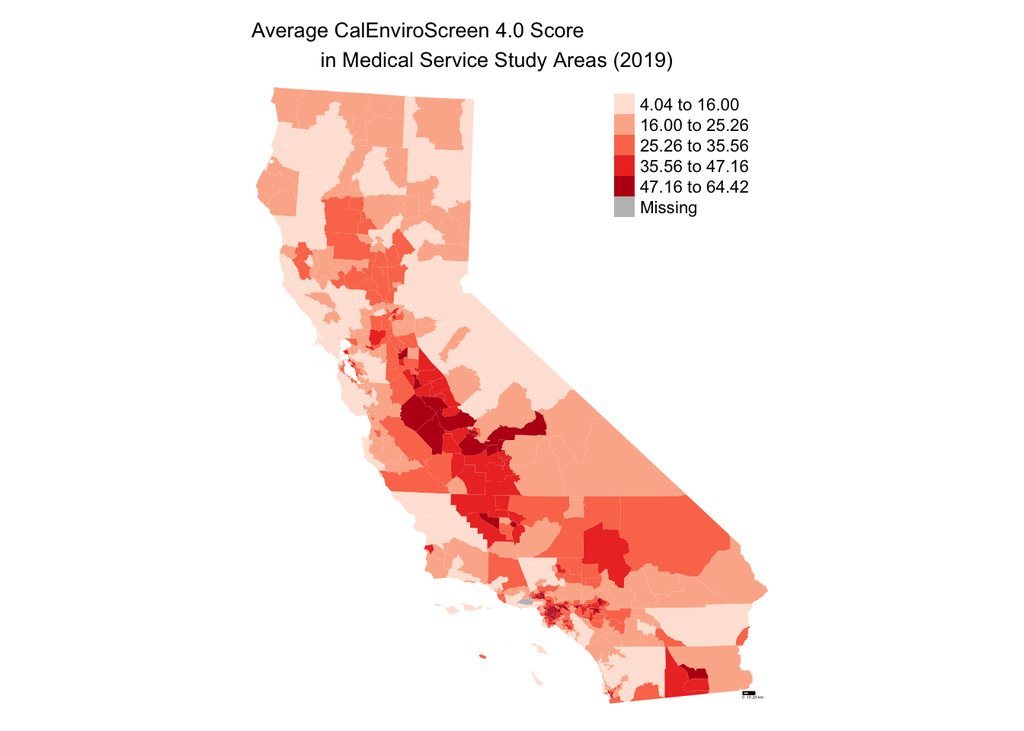

```r
# average enviroscreen score
tm_shape(mssa) +
  tm_polygons(col = "avgscore", style = "jenks", border.alpha = 0, palette = "Reds",
              title = "") +
  tm_scale_bar(breaks = c(0, 10, 20), text.size = 1) +
  tm_layout(main.title = "Average CalEnviroScreen 4.0 Score
            in Medical Service Study Areas (2019)",
            main.title.size = 0.85, frame = FALSE)
```

Number of State and Federal Correctional Facilities

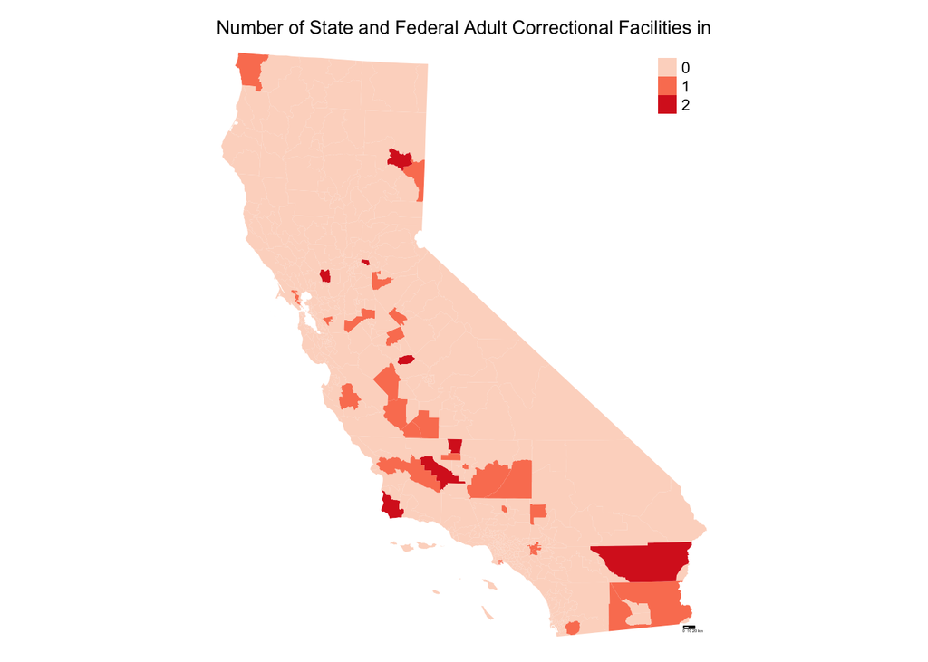

```r
# ssti rate
tm_shape(mssa) +
  tm_polygons(col = "prison", border.alpha = 0, palette = "Reds",
              title = "") +
  tm_scale_bar(breaks = c(0, 10, 20), text.size = 1) +
  tm_layout(main.title = "Number of State and Federal Adult Correctional Facilities in Medical Service Study Areas (2019)",
            main.title.size = 0.85, frame = FALSE)
```

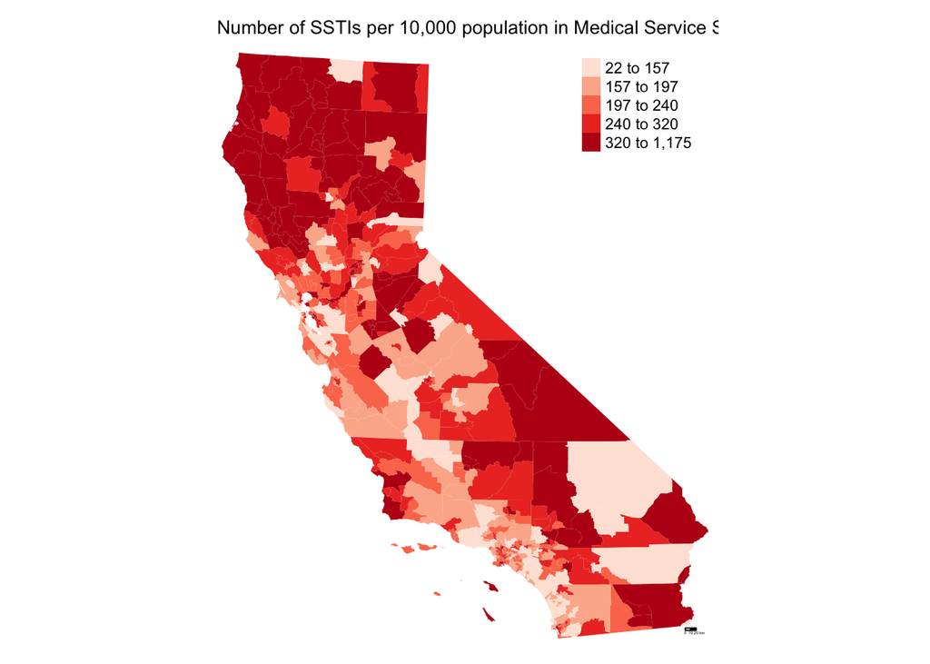

```r
# ssti rate
tm_shape(mssa) +
  tm_polygons(col = "sstirt", style = "quantile", border.alpha = 0, palette = "Reds",
              title = "") +
  tm_scale_bar(breaks = c(0, 10, 20), text.size = 1) +
  tm_layout(main.title = "Number of SSTIs per 10,000 population in Medical Service Study Areas (2019)",
            main.title.size = 0.85, frame = FALSE)
```

## 3. Bayesian Multilevel Regression Analysis

Research Question: *What MSSA-level area characteristics mediate the relationship between area-level poverty and higher odds of CA-MRSA infection in individuals?*

Will use regression-based difference method.

For logistic regression, the following assumptions must be made to interpret the direct and indirect effect causally (a DAG built in Dagity is used to meet the assumptions):

A1. Control must be made for exposure-outcome confounding  
A2. Control must be made for mediator-outcome confounding  
A3. Control must be made for exposure-mediator confounding  
A4. No mediator-outcome confounder that is itself affected by the exposure

Further, if the outcome is binary and rare (10% is often used as a cutoff), then you can use the logit link, otherwise it is recommended to use a log link. My outcome is ~2% in the population, but I randomly undersampled my non-cases to create a more balanced dataset where my cases are now 9% of each dataframe.

#### Create INLA Data Frame

```r
# remove Avalon MSSA with zero neighbors
map_inla <- mssa %>%
  filter(mssa != "Avalon")

# random effect to model spatial residual variation
map_inla$re_u <- 1:541

# create neighbor object
nb <- poly2nb(map_inla, queen = TRUE, row.names = map_inla$re_u)
nb2INLA("nb.adj", nb)
g <- inla.read.graph(filename = "nb.adj")

# create INLA df
df <- left_join(map_inla, sampled_df, by = c("mssa" = "mssa")) %>%
  dplyr::select(mssa, y, sexcat, race_eth, insurance, agec, rural = ruralflag,
                prison = prisonflag, hcsa, poverty, pollution, ind, re_u)

ch2_df1 <- subset(df, ind == 1)
# ch2_df2 <- subset(df, ind == 2)
```

#### Check Correlations

Categorical variables (chi-square test)

```r
# sex and insurance
chisq.test(df$sexcat, df$insurance)
```

```
##
##  Pearson's Chi-squared test
##
## data:  df$sexcat and df$insurance
## X-squared = 103661, df = 2, p-value < 2.2e-16
```

```r
# race/ethnicity and insurance
chisq.test(df$race_eth, df$insurance)
```

```
##
##  Pearson's Chi-squared test
##
## data:  df$race_eth and df$insurance
## X-squared = 250922, df = 8, p-value < 2.2e-16
```

```r
# race/ethnicity and hcsa
chisq.test(df$race_eth, df$hcsa)
```

```
##
##  Pearson's Chi-squared test
##
## data:  df$race_eth and df$hcsa
## X-squared = 425904, df = 4, p-value < 2.2e-16
```

```r
# rural and hcsa
chisq.test(df$rural, df$hcsa)
```

```
##
##  Pearson's Chi-squared test with Yates' continuity correction
##
## data:  df$rural and df$hcsa
## X-squared = 2553327, df = 1, p-value < 2.2e-16
```

```r
# rural and poverty
chisq.test(df$rural, df$poverty)
```

```
##
##  Pearson's Chi-squared test
##
## data:  df$rural and df$poverty
## X-squared = 166629, df = 3, p-value < 2.2e-16
```

```r
# rural and pollution
chisq.test(df$rural, df$pollution)
```

```
##
##  Pearson's Chi-squared test
##
## data:  df$rural and df$pollution
## X-squared = 190945, df = 3, p-value < 2.2e-16
```

```r
# pollution and hcsa
chisq.test(df$pollution, df$hcsa)
```

```
##
##  Pearson's Chi-squared test
##
## data:  df$pollution and df$hcsa
## X-squared = 2898457, df = 3, p-value < 2.2e-16
```

```r
# poverty and ca-mrsa
chisq.test(df$poverty, df$y)
```

```
##
##  Pearson's Chi-squared test
##
## data:  df$poverty and df$y
## X-squared = 5375.7, df = 3, p-value < 2.2e-16
```

#### 1) Mediators must be correlated with the predictor of interest.

Mediators under consideration include whether the MSSA is a healthcare shortage area, whether there is a state or federal corrections center in the MSSA, and the average pollution burden in the MSSA.

```r
library("MASS")
pov.hcsa <- data.frame(df$poverty, df$hcsa)
pov.hcsa = table(df$poverty, df$hcsa)
print(pov.hcsa)
```

```
##
##            0       1
##   Q1 4101647  134290
##   Q2 3765764  773745
##   Q3 3077762 1651422
##   Q4 1837220 3426238
```

```r
# poverty and hcsa
print(chisq.test(pov.hcsa))
```

```
##
##  Pearson's Chi-squared test
##
## data:  pov.hcsa
## X-squared = 4760765, df = 3, p-value < 2.2e-16
```

```r
pov.poll <- data.frame(df$poverty, df$pollution)
pov.poll = table(df$poverty, df$pollution)
print(pov.poll)
```

```
##
##           Q1      Q2      Q3      Q4
##   Q1 1952033 1495014  747711       0
##   Q2  410672 1569958 1755849  758732
##   Q3  186224  725858 1858593 1958509
##   Q4   42730  341677  885337 3993714
```

```r
# poverty and pollution
print(chisq.test(pov.poll))
```

```
##
##  Pearson's Chi-squared test
##
## data:  pov.poll
## X-squared = 10780658, df = 9, p-value < 2.2e-16
```

```r
pov.cf <- data.frame(df$poverty, df$prison)
pov.cf = table(df$poverty, df$prison)
print(pov.cf)
```

```
##
##            0       1
##   Q1 4056810  179127
##   Q2 4271560  267949
##   Q3 4626238  102946
##   Q4 4836702  426756
```

```r
# poverty and hcsa
print(chisq.test(pov.cf))
```

```
##
##  Pearson's Chi-squared test
##
## data:  pov.cf
## X-squared = 190462, df = 3, p-value < 2.2e-16
```

**2) Difference Method (more frequent in epidemiology)**

Fit two regression models:

1. Y on exposure A and covariates C
2. Y on exposure A and covariates C with mediator M

If the exposure coefficient of the first regression, without the mediator, goes down considerably when comparing it to the exposure coefficient in the second regression, when adding the mediator, this is thought to be indicative of mediation. The difference between these two coefficients is sometimes interpreted as a “mediated” of “indirect effect”.

Exposure coefficient in the model that includes the mediator is taken to be the “direct effect”.

```r
df <- as.data.frame(ch2_df1)

# base model
set.seed(0111)
base <- inla(y ~ poverty + race_eth + sexcat + insurance + agec +
               f(re_u, model = "iid"), family = "binomial",
             Ntrials = 1, data = df,
             control.family = list(link = "logit"),
             control.inla = list(int.strategy = "eb"),
             control.compute = list(waic = TRUE))

# spatial model
set.seed(0112)
spatial <- inla(y ~ poverty + race_eth + sexcat + insurance + agec +
                  f(re_u, model = "bym",
                    hyper = "pc",
                    graph = g, scale.model = TRUE),
                family = "binomial", Ntrials = 1, data = df,
                control.family = list(link = "logit"),
                control.inla = list(int.strategy = "eb"),
                control.compute = list(waic = TRUE))

# hcsa
set.seed(0113)
hcsa <- inla(y ~ poverty + race_eth + sexcat + insurance + agec + hcsa +
               f(re_u, model = "bym",
                 hyper = "pc",
                 graph = g, scale.model = TRUE),
             family = "binomial", Ntrials = 1, data = df,
             control.family = list(link = "logit"),
             control.inla = list(int.strategy = "eb"),
             control.compute = list(waic = TRUE))

# prison
set.seed(0114)
cf <- inla(y ~ poverty + race_eth + sexcat + insurance + agec + prison +
             f(re_u, model = "bym",
               hyper = "pc",
               graph = g, scale.model = TRUE),
           family = "binomial", Ntrials = 1, data = df,
           control.family = list(link = "logit"),
           control.inla = list(int.strategy = "eb"),
           control.compute = list(waic = TRUE))

# pollution
set.seed(0115)
pollution <- inla(y ~ poverty + race_eth + sexcat + insurance + agec + pollution +
                    f(re_u, model = "bym",
                      hyper = "pc",
                      graph = g, scale.model = TRUE),
           family = "binomial", Ntrials = 1, data = df,
           control.family = list(link = "logit"),
           control.inla = list(int.strategy = "eb"),
           control.compute = list(waic = TRUE))

# full model
set.seed(0116)
full <- inla(y ~ poverty + race_eth + sexcat + insurance + agec + hcsa +prison + pollution +
               f(re_u, model = "bym",
                 hyper = "pc", graph = g, scale.model = TRUE),
             family = "binomial", Ntrials = 1, data = df,
             control.family = list(link = "logit"),
             control.inla = list(int.strategy = "eb"),
             control.compute = list(waic = TRUE))
```

**Pollution Indicators**

```r
# wrangling
load(file = "/Users/brittanymorgan/Desktop/Data/map_inla")

# water bodies is the average number of pollutants across all water bodies designated as impaired within the MSSA
# groundwater is the average weighted score for sites that threaten groundwater within the MSSA
indicators <- as.data.frame(map_inla) %>%
  dplyr::select(mssa, waterbodies, groundwater)

cuts3 = quantile(indicators$waterbodies, c(0, 1/4, 2/4, 3/4, 1), na.rm = TRUE)
cuts4 = quantile(indicators$groundwater, c(0, 1/4, 2/4, 3/4, 1), na.rm = TRUE)
df_2 <- left_join(indicators, df, by = c("mssa" = "mssa")) %>%
        mutate(water = cut(waterbodies, breaks = cuts3,
                             labels = c("Q1", "Q2", "Q3", "Q4"), include.lowest = TRUE),
               ground = cut(groundwater, breaks = cuts4,
                             labels = c("Q1", "Q2", "Q3", "Q4"), include.lowest = TRUE))

# waterbodies
set.seed(0117)
water <- inla(y ~ poverty + race_eth + sexcat + insurance + agec + water +
                    f(re_u, model = "bym",
                      hyper = "pc",
                      graph = g, scale.model = TRUE),
           family = "binomial", Ntrials = 1, data = df_2,
           control.family = list(link = "logit"),
           control.inla = list(int.strategy = "eb"),
           control.compute = list(waic = TRUE))

# groundwater
set.seed(0118)
ground <- inla(y ~ poverty + race_eth + sexcat + insurance + agec + ground +
                    f(re_u, model = "bym",
                      hyper = "pc",
                      graph = g, scale.model = TRUE),
           family = "binomial", Ntrials = 1, data = df_2,
           control.family = list(link = "logit"),
           control.inla = list(int.strategy = "eb"),
           control.compute = list(waic = TRUE))
```

#### 4) Inference

**Exponentiate Parameters**

```r
# base model
base_fixed <- exp(base$summary.fixed[-1, c(3,4,5)])
base_fixed
```

```
##                    0.025quant  0.5quant 0.975quant
## povertyQ2           1.0229515 1.0607389  1.0999222
## povertyQ3           1.0715597 1.1111594  1.1522224
## povertyQ4           1.0799489 1.1200035  1.1615436
## race_ethhispanic    0.7523121 0.7566225  0.7609575
## race_ethnhapi       0.6377499 0.6437755  0.6498580
## race_ethnhblack     0.6881354 0.6939317  0.6997769
## race_ethother       0.9941338 1.0254373  1.0577265
## sexcatmale          1.6113585 1.6186941  1.6260630
## insurancepublic     1.4506844 1.4589730  1.4673090
## insuranceuninsured  1.5104941 1.5240981  1.5378247
## agec18-34           1.5177909 1.5289139  1.5401183
## agec35-64           1.7645887 1.7766483  1.7887903
```

```r
# spatial model
spatial_fixed <- exp(spatial$summary.fixed[-1, c(3,4,5)])
spatial_fixed
```

```
##                    0.025quant  0.5quant 0.975quant
## povertyQ2           1.0118483 1.0402541  1.0694574
## povertyQ3           1.0375728 1.0695349  1.1024816
## povertyQ4           1.0532631 1.0888664  1.1256732
## race_ethhispanic    0.7528649 0.7571847  0.7615293
## race_ethnhapi       0.6377944 0.6438233  0.6499093
## race_ethnhblack     0.6885235 0.6943293  0.7001840
## race_ethother       0.9901542 1.0212622  1.0533474
## sexcatmale          1.6112677 1.6186028  1.6259712
## insurancepublic     1.4504024 1.4586887  1.4670224
## insuranceuninsured  1.5102649 1.5238665  1.5375906
## agec18-34           1.5179381 1.5290613  1.5402660
## agec35-64           1.7648505 1.7769110  1.7890538
```

```r
# hcsa model
hcsa_fixed <- exp(hcsa$summary.fixed[-1, c(3,4,5)])
hcsa_fixed
```

```
##                    0.025quant  0.5quant 0.975quant
## povertyQ2           1.0089357 1.0370970  1.0660443
## povertyQ3           1.0277777 1.0599968  1.0932260
## povertyQ4           1.0376772 1.0742029  1.1120143
## race_ethhispanic    0.7528202 0.7571398  0.7614841
## race_ethnhapi       0.6378193 0.6438485  0.6499347
## race_ethnhblack     0.6885330 0.6943389  0.7001937
## race_ethother       0.9902590 1.0213669  1.0534521
## sexcatmale          1.6112688 1.6186039  1.6259724
## insurancepublic     1.4503638 1.4586499  1.4669834
## insuranceuninsured  1.5102458 1.5238472  1.5375711
## agec18-34           1.5179452 1.5290684  1.5402731
## agec35-64           1.7648457 1.7769061  1.7890489
## hcsa                1.0074233 1.0335331  1.0603195
```

```r
# cf model
cf_fixed <- exp(cf$summary.fixed[-1, c(3,4,5)])
cf_fixed
```

```
##                    0.025quant  0.5quant 0.975quant
## povertyQ2           1.0125079 1.0408645  1.0700152
## povertyQ3           1.0376853 1.0695587  1.1024111
## povertyQ4           1.0554644 1.0911191  1.1279782
## race_ethhispanic    0.7528704 0.7571901  0.7615347
## race_ethnhapi       0.6377944 0.6438233  0.6499092
## race_ethnhblack     0.6885196 0.6943253  0.7001800
## race_ethother       0.9899940 1.0210969  1.0531770
## sexcatmale          1.6112785 1.6186137  1.6259822
## insurancepublic     1.4504050 1.4586913  1.4670250
## insuranceuninsured  1.5102614 1.5238630  1.5375870
## agec18-34           1.5179507 1.5290740  1.5402788
## agec35-64           1.7648633 1.7769239  1.7890668
## prison              0.9304219 0.9668938  1.0047955
```

```r
# pollution model
pollution_fixed <- exp(pollution$summary.fixed[-1, c(3,4,5)])
pollution_fixed
```

```
##                    0.025quant  0.5quant 0.975quant
## povertyQ2           0.9955857 1.0256315  1.0565841
## povertyQ3           1.0142542 1.0505134  1.0880688
## povertyQ4           1.0243761 1.0673163  1.1120564
## race_ethhispanic    0.7527435 0.7570648  0.7614110
## race_ethnhapi       0.6377240 0.6437524  0.6498379
## race_ethnhblack     0.6884295 0.6942352  0.7000899
## race_ethother       0.9906289 1.0217525  1.0538540
## sexcatmale          1.6112890 1.6186242  1.6259928
## insurancepublic     1.4503200 1.4586061  1.4669396
## insuranceuninsured  1.5102160 1.5238173  1.5375410
## agec18-34           1.5178158 1.5289384  1.5401426
## agec35-64           1.7647178 1.7767777  1.7889201
## pollutionQ2         1.0048089 1.0352301  1.0665722
## pollutionQ3         1.0097057 1.0456834  1.0829431
## pollutionQ4         0.9978767 1.0446148  1.0935419
```

```r
# full model
full_fixed <- exp(full$summary.fixed[-1, c(3,4,5)])
full_fixed
```

```
##                    0.025quant  0.5quant 0.975quant
## povertyQ2           0.9960704 1.0258402  1.0564997
## povertyQ3           1.0109801 1.0469256  1.0841491
## povertyQ4           1.0205974 1.0634679  1.1081391
## race_ethhispanic    0.7527474 0.7570686  0.7614147
## race_ethnhapi       0.6377609 0.6437899  0.6498758
## race_ethnhblack     0.6884628 0.6942689  0.7001239
## race_ethother       0.9904417 1.0215568  1.0536495
## sexcatmale          1.6112970 1.6186323  1.6260009
## insurancepublic     1.4503029 1.4585889  1.4669222
## insuranceuninsured  1.5102061 1.5238072  1.5375308
## agec18-34           1.5178536 1.5289765  1.5401809
## agec35-64           1.7647452 1.7768053  1.7889478
## hcsa                1.0058818 1.0324678  1.0597564
## prison              0.9320665 0.9681894  1.0057123
## pollutionQ2         1.0030699 1.0331915  1.0642177
## pollutionQ3         1.0037753 1.0395025  1.0765013
## pollutionQ4         0.9839914 1.0307163  1.0796599
```

```r
# waterbodies
water_fixed <- exp(water$summary.fixed[-1, c(3,4,5)])
water_fixed
```

```
##                    0.025quant  0.5quant 0.975quant
## povertyQ2           1.0108034 1.0393712  1.0687465
## povertyQ3           1.0363616 1.0683758  1.1013790
## povertyQ4           1.0509912 1.0868606  1.1239542
## race_ethhispanic    0.7528735 0.7571935  0.7615383
## race_ethnhapi       0.6377988 0.6438278  0.6499138
## race_ethnhblack     0.6885188 0.6943246  0.7001795
## race_ethother       0.9902708 1.0213837  1.0534741
## sexcatmale          1.6112727 1.6186079  1.6259764
## insurancepublic     1.4504319 1.4587186  1.4670526
## insuranceuninsured  1.5102943 1.5238962  1.5376207
## agec18-34           1.5179460 1.5290693  1.5402741
## agec35-64           1.7648646 1.7769253  1.7890683
## waterQ2             0.9862380 1.0155181  1.0456676
## waterQ3             0.9783995 1.0091437  1.0408539
## waterQ4             0.9926292 1.0281688  1.0649808
```

```r
# groundwater
ground_fixed <- exp(ground$summary.fixed[-1, c(3,4,5)])
ground_fixed
```

```
##                    0.025quant  0.5quant 0.975quant
## povertyQ2           1.0065145 1.0349776  1.0642455
## povertyQ3           1.0285850 1.0608175  1.0940600
## povertyQ4           1.0440814 1.0799045  1.1169568
## race_ethhispanic    0.7528548 0.7571745  0.7615190
## race_ethnhapi       0.6377794 0.6438082  0.6498940
## race_ethnhblack     0.6885001 0.6943057  0.7001602
## race_ethother       0.9904639 1.0215870  1.0536881
## sexcatmale          1.6112708 1.6186059  1.6259744
## insurancepublic     1.4504093 1.4586957  1.4670295
## insuranceuninsured  1.5102672 1.5238689  1.5375930
## agec18-34           1.5178918 1.5290147  1.5402191
## agec35-64           1.7648154 1.7768757  1.7890183
## groundQ2            0.9711909 1.0004744  1.0306407
## groundQ3            0.9851333 1.0169700  1.0498357
## groundQ4            1.0034642 1.0391190  1.0760407
```

## Model Checking & Diagnostics

#### 1) Evaluate random effect for full model

```r
# SD for random effects rather than precision
bri.hyperpar.summary(full)
```

```
##                                       mean          sd     q0.025       q0.5
## SD for re_u (idd component)     0.03460547 0.008753252 0.01833414 0.03454226
## SD for re_u (spatial component) 0.16729970 0.010164889 0.15109626 0.16591024
##                                     q0.975       mode
## SD for re_u (idd component)     0.05170028 0.03441439
## SD for re_u (spatial component) 0.19044210 0.16188082
```

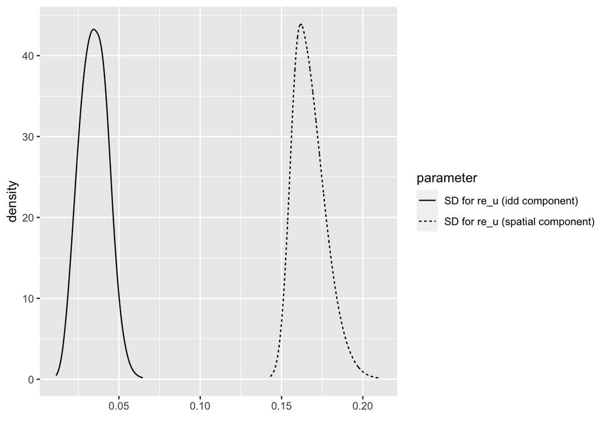

```r
# plot density of the whole posterior distribution for the SD
bri.hyperpar.plot(full)
```

```r
# SD posterior distribution (transformed to odds)
exp(bri.hyperpar.summary(full)[3:5])
```

```
## [1] 1.008792 1.010217 1.018503
```

```r
# WAIC
base$waic$waic
```

```
## [1] 5555815
```

```r
spatial$waic$waic
```

```
## [1] 5555784
```

```r
hcsa$waic$waic
```

```
## [1] 5555784
```

```r
cf$waic$waic
```

```
## [1] 5555785
```

```r
pollution$waic$waic
```

```
## [1] 5555783
```

```r
full$waic$waic
```

```
## [1] 5555784
```

## **Sensitivity Analyses**

#### 1) Priors

Used generic PC Prior for the hyperparameter of the latent effect, will test different values for precision of prior

```r
# pc priors
"pc: generic PC-prior where alpha is set to a value close to the minimum value of alpha allowed"
```

```
## [1] "pc: generic PC-prior where alpha is set to a value close to the minimum value of alpha allowed"
```

```r
"theta 1: log precision prior with param (1, 0.01), initial value = 4"
```

```
## [1] "theta 1: log precision prior with param (1, 0.01), initial value = 4"
```

```r
"theta2: logitphi with param (0.5, 0.5), initial value = -3)"
```

```
## [1] "theta2: logitphi with param (0.5, 0.5), initial value = -3)"
```

```r
set.seed(0119)
pc_theta1 <- inla(y ~ poverty + sexcat + race_eth + insurance + agec + hcsa + prison +
                    pollution + f(re_u,
                                  model = "bym", graph = g,
                                  hyper = "theta1", scale.model = TRUE),
                  family = "binomial", Ntrials = 1, data = df,
                  control.family = list(link = "logit"),
                  control.inla = list(int.strategy = "eb"),
                  control.compute = list(waic = TRUE))

set.seed(0120)
pc_theta2 <- inla(y ~ poverty + sexcat + race_eth + insurance + agec + hcsa + prison +
                    pollution + f(re_u,
                                  model = "bym", graph = g,
                                  hyper = "theta2", scale.model = TRUE),
                  family = "binomial", Ntrials = 1, data = df,
                  control.family = list(link = "logit"),
                  control.inla = list(int.strategy = "eb"),
                  control.compute = list(waic = TRUE))
```

```r
theta1.sens <- exp(pc_theta1$summary.fixed[-1, c(3,4,5)])
theta1.sens
```

```
##                    0.025quant  0.5quant 0.975quant
## povertyQ2           0.9960704 1.0258402  1.0564997
## povertyQ3           1.0109801 1.0469256  1.0841491
## povertyQ4           1.0205974 1.0634679  1.1081391
## sexcatmale          1.6112970 1.6186323  1.6260009
## race_ethhispanic    0.7527474 0.7570686  0.7614147
## race_ethnhapi       0.6377609 0.6437899  0.6498758
## race_ethnhblack     0.6884628 0.6942689  0.7001239
## race_ethother       0.9904417 1.0215568  1.0536495
## insurancepublic     1.4503029 1.4585889  1.4669222
## insuranceuninsured  1.5102061 1.5238072  1.5375308
## agec18-34           1.5178536 1.5289765  1.5401809
## agec35-64           1.7647452 1.7768053  1.7889478
## hcsa                1.0058818 1.0324678  1.0597564
## prison              0.9320665 0.9681894  1.0057123
## pollutionQ2         1.0030699 1.0331915  1.0642177
## pollutionQ3         1.0037753 1.0395025  1.0765013
## pollutionQ4         0.9839914 1.0307163  1.0796599
```

```r
theta2.sens <- exp(pc_theta2$summary.fixed[-1, c(3,4,5)])
theta2.sens
```

```
##                    0.025quant  0.5quant 0.975quant
## povertyQ2           0.9960704 1.0258402  1.0564997
## povertyQ3           1.0109801 1.0469256  1.0841491
## povertyQ4           1.0205974 1.0634679  1.1081391
## sexcatmale          1.6112970 1.6186323  1.6260009
## race_ethhispanic    0.7527474 0.7570686  0.7614147
## race_ethnhapi       0.6377609 0.6437899  0.6498758
## race_ethnhblack     0.6884628 0.6942689  0.7001239
## race_ethother       0.9904417 1.0215568  1.0536495
## insurancepublic     1.4503029 1.4585889  1.4669222
## insuranceuninsured  1.5102061 1.5238072  1.5375308
## agec18-34           1.5178536 1.5289765  1.5401809
## agec35-64           1.7647452 1.7768053  1.7889478
## hcsa                1.0058818 1.0324678  1.0597564
## prison              0.9320665 0.9681894  1.0057123
## pollutionQ2         1.0030699 1.0331915  1.0642177
## pollutionQ3         1.0037753 1.0395025  1.0765013
## pollutionQ4         0.9839914 1.0307163  1.0796599
```

Did not change model results

#### 2) Moderation Analysis

Will evaluate the potential moderation effects of pollution since it was the most significant mediator and the variable that supports the mediation vs. moderation hypothesis most, theoretically.

```r
# pollution moderation
set.seed(0121)
moderation <- inla(y ~ poverty + race_eth + sexcat + insurance + agec + poverty*pollution +
                    f(re_u, model = "bym",
                      hyper = "pc",
                      graph = g, scale.model = TRUE),
           family = "binomial", Ntrials = 1, data = df,
           control.family = list(link = "logit"),
           control.inla = list(int.strategy = "eb"),
           control.compute = list(waic = TRUE))

mod_fixed <- exp(moderation$summary.fixed[-1, c(3,4,5)])
mod_fixed
```

```
##                         0.025quant  0.5quant   0.975quant
## povertyQ2             9.922412e-01 1.0457725 1.102192e+00
## povertyQ3             9.721047e-01 1.0421315 1.117203e+00
## povertyQ4             1.030869e+00 1.1343738 1.248271e+00
## race_ethhispanic      7.527942e-01 0.7571162 7.614629e-01
## race_ethnhapi         6.377602e-01 0.6437892 6.498751e-01
## race_ethnhblack       6.884725e-01 0.6942788 7.001341e-01
## race_ethother         9.902422e-01 1.0213891 1.053516e+00
## sexcatmale            1.611244e+00 1.6185789 1.625947e+00
## insurancepublic       1.450262e+00 1.4585475 1.466881e+00
## insuranceuninsured    1.510159e+00 1.5237596 1.537483e+00
## agec18-34             1.517764e+00 1.5288860 1.540090e+00
## agec35-64             1.764632e+00 1.7766912 1.788833e+00
## pollutionQ2           9.952069e-01 1.0383873 1.083441e+00
## pollutionQ3           1.018776e+00 1.0777325 1.140100e+00
## pollutionQ4           3.550183e-14 1.0208005 2.935155e+13
## povertyQ2:pollutionQ2 9.083923e-01 0.9717627 1.039554e+00
## povertyQ3:pollutionQ2 9.726125e-01 1.0578917 1.150648e+00
## povertyQ4:pollutionQ2 8.089769e-01 0.9069292 1.016742e+00
## povertyQ2:pollutionQ3 8.876945e-01 0.9590801 1.036206e+00
## povertyQ3:pollutionQ3 8.851959e-01 0.9664077 1.055070e+00
## povertyQ4:pollutionQ3 8.292060e-01 0.9270406 1.036418e+00
## povertyQ2:pollutionQ4 3.541068e-14 1.0182113 2.927801e+13
## povertyQ3:pollutionQ4 3.598688e-14 1.0347788 2.975437e+13
## povertyQ4:pollutionQ4 3.369293e-14 0.9688475 2.785942e+13
```

Not a significant moderator.

#### 3) Subset of only subcutaneous abscess

```r
load(file = "/Users/brittanymorgan/Desktop/Data/df.full")

# include only ICD-10 for abscess (L02) as cases
df.mrsa <- df.full %>%
  filter(str_detect(dx_prin, "L02")) %>% # 294964 cases
  mutate(mrsa = 1)
codes <- unique(df.mrsa$dx_prin)
df.mrsa0 <- df.full %>%
  filter(! dx_prin %in% codes) %>%
  mutate(mrsa = 0)

df.full <- rbind(df.mrsa, df.mrsa0, fill = TRUE)

# remove individuals in Avalon MSSA from the analysis (has no neighbors and is an island)
df.full <- df.full %>%
  filter(mssa != "Avalon")

# filter cases (n = 294,964)
cases <- df.full %>%
  filter(mrsa == 1)

# filter non-cases
noncases <- df.full %>%
  filter(mrsa == 0)

remove(df.full, df.mrsa, df.mrsa0)

# random sample noncases
set.seed(99013)
rand <- noncases[sample(nrow(noncases), size = 2982414), ]

sampled_df <- rbind(cases, rand)

remove(cases, noncases, rand, codes)

# outcome (ssti)
sampled_df$y <- ifelse(sampled_df$ssti == 1, 1, 0)

# sex, female as reference
sampled_df$sexcat <- car::Recode(sampled_df$sex, recodes = "'M' = 'male';
                                                 'F' = 'female';
                                                  else = NA", as.factor = T)
sampled_df$sexcat <- relevel(sampled_df$sexcat, ref = "female")

# race/ethnicity
sampled_df$race_eth <- car::Recode(sampled_df$racegrp, recodes = "'NH-White' = 'nhwhite';
                                                            'NH-Black' = 'nhblack';
                                                            'NH-Asian' = 'nhapi';
                                                            'NH-Islander' = 'nhapi';
                                                            'Hispanic' = 'hispanic';
                                                            'NH-AIAN' = 'other';
                                                            'Other' = 'other';
                                                            else = NA", as.factor = T)
sampled_df$race_eth <- relevel(sampled_df$race_eth, ref = "nhwhite")

# insurance, private as reference
sampled_df$insurance <- car::Recode(sampled_df$insure, recodes = "'private' = 'private';
                                                           'public' = 'public';
                                                           'uninsured' = 'uninsured';
                                                           else = NA", as.factor = T)
sampled_df$insurance <- relevel(sampled_df$insurance, ref = "private")

# age category, 65 and over as reference
sampled_df$agec <- car::Recode(sampled_df$agecat, recodes = "'18-34' = '18-34';
                                                      '35-64' = '35-64';
                                                      '65+' = '65 and over';
                                                      else = NA", as.factor = T)
sampled_df$agec <- relevel(sampled_df$agec, ref = "65 and over")

df_abscess <- left_join(map_inla, sampled_df, by = c("mssa" = "mssa")) %>%
  dplyr::select(mssa, y, sexcat, race_eth, insurance, agec, rural = ruralflag,
                prison = prisonflag, hcsa, poverty, pollution, re_u)

remove(sampled_df)
```

```r
df_abscess <- as.data.frame(df_abscess)

# base model
set.seed(0122)
base_abscess <- inla(y ~ poverty + race_eth + sexcat + insurance + agec +
                       f(re_u, model = "iid"),
             family = "binomial", Ntrials = 1, data = df_abscess,
             control.family = list(link = "logit"),
             control.inla = list(int.strategy = "eb"),
             control.compute = list(waic = TRUE))

# spatial
set.seed(0123)
spatial_abscess <- inla(y ~ poverty + race_eth + sexcat + insurance + agec +
                       f(re_u, model = "bym",
                         hyper = "pc", graph = g, scale.model = TRUE),
             family = "binomial", Ntrials = 1, data = df_abscess,
             control.family = list(link = "logit"),
             control.inla = list(int.strategy = "eb"),
             control.compute = list(waic = TRUE))

# hcsa
set.seed(0124)
hcsa_abscess <- inla(y ~ poverty + race_eth + sexcat + insurance + agec + hcsa +
                       f(re_u, model = "bym",
                         hyper = "pc", graph = g, scale.model = TRUE),
             family = "binomial", Ntrials = 1, data = df_abscess,
             control.family = list(link = "logit"),
             control.inla = list(int.strategy = "eb"),
             control.compute = list(waic = TRUE))

# cf
set.seed(0125)
cf_abscess <- inla(y ~ poverty + race_eth + sexcat + insurance + agec + prison +
                       f(re_u, model = "bym",
                         hyper = "pc", graph = g, scale.model = TRUE),
             family = "binomial", Ntrials = 1, data = df_abscess,
             control.family = list(link = "logit"),
             control.inla = list(int.strategy = "eb"),
             control.compute = list(waic = TRUE))

# pollution
set.seed(0126)
pollution_abscess <- inla(y ~ poverty + race_eth + sexcat + insurance + agec + pollution +
                       f(re_u, model = "bym",
                         hyper = "pc", graph = g, scale.model = TRUE),
             family = "binomial", Ntrials = 1, data = df_abscess,
             control.family = list(link = "logit"),
             control.inla = list(int.strategy = "eb"),
             control.compute = list(waic = TRUE))

# full
set.seed(0127)
full_abscess <- inla(y ~ poverty + race_eth + sexcat + insurance + agec + hcsa +
                       prison + pollution + f(re_u, model = "bym",
                                              hyper = "pc", graph = g, scale.model = TRUE),
             family = "binomial", Ntrials = 1, data = df_abscess,
             control.family = list(link = "logit"),
             control.inla = list(int.strategy = "eb"),
             control.compute = list(waic = TRUE))
```

```r
# base abscess
base_fixed_ab <- exp(base_abscess$summary.fixed[-1, c(3,4,5)])
base_fixed_ab
```

```
##                    0.025quant  0.5quant 0.975quant
## povertyQ2           1.0206560 1.0678709  1.1172700
## povertyQ3           1.1092397 1.1604738  1.2140743
## povertyQ4           1.1492337 1.2024557  1.2581425
## race_ethhispanic    0.8119173 0.8193405  0.8268315
## race_ethnhapi       0.6896798 0.7002255  0.7109324
## race_ethnhblack     0.8695229 0.8805921  0.8918021
## race_ethother       1.0446520 1.0974519  1.1529204
## sexcatmale          1.6585210 1.6706332  1.6828339
## insurancepublic     1.5774812 1.5920000  1.6066524
## insuranceuninsured  1.6892867 1.7128166  1.7366743
## agec18-34           3.1258743 3.1686864  3.2120848
## agec35-64           2.9881039 3.0277740  3.0679708
```

```r
# spatial abscess
spatial_fixed_ab <- exp(spatial_abscess$summary.fixed[-1, c(3,4,5)])
spatial_fixed_ab
```

```
##                    0.025quant  0.5quant 0.975quant
## povertyQ2           1.0231125 1.0590657  1.0962823
## povertyQ3           1.0705640 1.1118906  1.1548126
## povertyQ4           1.0970911 1.1434664  1.1918020
## race_ethhispanic    0.8130244 0.8204772  0.8279984
## race_ethnhapi       0.6899854 0.7005448  0.7112658
## race_ethnhblack     0.8708875 0.8819972  0.8932487
## race_ethother       1.0344883 1.0866305  1.1414009
## sexcatmale          1.6584449 1.6705565  1.6827566
## insurancepublic     1.5771658 1.5916801  1.6063279
## insuranceuninsured  1.6891384 1.7126652  1.7365197
## agec18-34           3.1271448 3.1699704  3.2133825
## agec35-64           2.9896534 3.0293408  3.0695550
```

```r
# hcsa abscess
hcsa_fixed_ab <- exp(hcsa_abscess$summary.fixed[-1, c(3,4,5)])
hcsa_fixed_ab
```

```
##                    0.025quant  0.5quant 0.975quant
## povertyQ2           1.0213443 1.0572567  1.0944318
## povertyQ3           1.0636493 1.1056049  1.1492155
## povertyQ4           1.0851817 1.1332406  1.1834278
## race_ethhispanic    0.8129839 0.8204366  0.8279576
## race_ethnhapi       0.6900217 0.7005819  0.7113037
## race_ethnhblack     0.8709091 0.8820192  0.8932710
## race_ethother       1.0344843 1.0866249  1.1413935
## sexcatmale          1.6584469 1.6705585  1.6827586
## insurancepublic     1.5771214 1.5916354  1.6062829
## insuranceuninsured  1.6891231 1.7126498  1.7365041
## agec18-34           3.1271576 3.1699834  3.2133956
## agec35-64           2.9896368 3.0293240  3.0695379
## hcsa                0.9898485 1.0222792  1.0557725
```

```r
# cf abscess
cf_fixed_ab <- exp(cf_abscess$summary.fixed[-1, c(3,4,5)])
cf_fixed_ab
```

```
##                    0.025quant  0.5quant 0.975quant
## povertyQ2           1.0236596 1.0596064  1.0968154
## povertyQ3           1.0706774 1.1119605  1.1548353
## povertyQ4           1.0987664 1.1452779  1.1937582
## race_ethhispanic    0.8130335 0.8204864  0.8280076
## race_ethnhapi       0.6899871 0.7005466  0.7112676
## race_ethnhblack     0.8708797 0.8819893  0.8932406
## race_ethother       1.0342869 1.0864202  1.1411812
## sexcatmale          1.6584533 1.6705650  1.6827651
## insurancepublic     1.5771659 1.5916801  1.6063279
## insuranceuninsured  1.6891348 1.7126615  1.7365160
## agec18-34           3.1271783 3.1700044  3.2134170
## agec35-64           2.9896791 3.0293669  3.0695815
## prison              0.9296240 0.9751534  1.0229127
```

```r
# pollution abscess
pollution_fixed_ab <- exp(pollution_abscess$summary.fixed[-1, c(3,4,5)])
pollution_fixed_ab
```

```
##                    0.025quant  0.5quant 0.975quant
## povertyQ2           0.9957341 1.0334333  1.0725599
## povertyQ3           1.0282805 1.0744301  1.1226508
## povertyQ4           1.0432868 1.0981348  1.1558662
## race_ethhispanic    0.8125961 0.8200507  0.8275736
## race_ethnhapi       0.6897805 0.7003372  0.7110554
## race_ethnhblack     0.8705148 0.8816221  0.8928711
## race_ethother       1.0358402 1.0880459  1.1428828
## sexcatmale          1.6584908 1.6706028  1.6828032
## insurancepublic     1.5769028 1.5914152  1.6060610
## insuranceuninsured  1.6889675 1.7124920  1.7363442
## agec18-34           3.1264427 3.1692600  3.2126637
## agec35-64           2.9890301 3.0287104  3.0689176
## pollutionQ2         1.0121794 1.0512425  1.0918132
## pollutionQ3         1.0304046 1.0772317  1.1261870
## pollutionQ4         1.0259834 1.0868275  1.1512797
```

```r
# full abscess
full_fixed_ab <- exp(full_abscess$summary.fixed[-1, c(3,4,5)])
full_fixed_ab
```

```
##                    0.025quant  0.5quant 0.975quant
## povertyQ2           0.9963357 1.0340361  1.0731630
## povertyQ3           1.0268154 1.0730083  1.1212792
## povertyQ4           1.0415867 1.0969127  1.1551775
## race_ethhispanic    0.8126139 0.8200687  0.8275918
## race_ethnhapi       0.6898211 0.7003786  0.7110978
## race_ethnhblack     0.8705532 0.8816614  0.8929112
## race_ethother       1.0355508 1.0877440  1.1425677
## sexcatmale          1.6584972 1.6706092  1.6828097
## insurancepublic     1.5768870 1.5913992  1.6060450
## insuranceuninsured  1.6889654 1.7124899  1.7363421
## agec18-34           3.1265144 3.1693328  3.2127377
## agec35-64           2.9890681 3.0287491  3.0689568
## hcsa                0.9834418 1.0162833  1.0502215
## prison              0.9320780 0.9774603  1.0250522
## pollutionQ2         1.0109934 1.0500105  1.0905334
## pollutionQ3         1.0270368 1.0739894  1.1230884
## pollutionQ4         1.0174238 1.0790342  1.1443754
```

## Present Results

#### 1) Forest Plot

```r
effects <- read.csv(file = "/Users/brittanymorgan/Desktop/Data/Forest Plot.csv")
plot <- effects %>%
  dplyr::select(Model, Variable, OR = OR1, Upper = Upper1, Lower = Lower1)

# color palette
library(RColorBrewer)

# plot
rev(plot)
```

```
##    Lower Upper    OR   Variable   Model
## 1  1.023 1.100 1.061 Poverty Q2 Model 1
## 2  1.072 1.152 1.111 Poverty Q3 Model 1
## 3  1.080 1.162 1.120 Poverty Q4 Model 1
## 4  1.012 1.069 1.040 Poverty Q2 Model 2
## 5  1.038 1.102 1.070 Poverty Q3 Model 2
## 6  1.053 1.126 1.089 Poverty Q4 Model 2
## 7  1.009 1.066 1.037 Poverty Q2 Model 3
## 8  1.028 1.093 1.060 Poverty Q3 Model 3
## 9  1.038 1.112 1.074 Poverty Q4 Model 3
## 10 1.013 1.070 1.041 Poverty Q2 Model 4
## 11 1.038 1.102 1.070 Poverty Q3 Model 4
## 12 1.055 1.128 1.091 Poverty Q4 Model 4
## 13 0.996 1.057 1.026 Poverty Q2 Model 5
## 14 1.014 1.088 1.051 Poverty Q3 Model 5
## 15 1.024 1.112 1.067 Poverty Q4 Model 5
## 16 0.996 1.056 1.026 Poverty Q2 Model 6
## 17 1.011 1.084 1.047 Poverty Q3 Model 6
## 18 1.021 1.108 1.063 Poverty Q4 Model 6
```

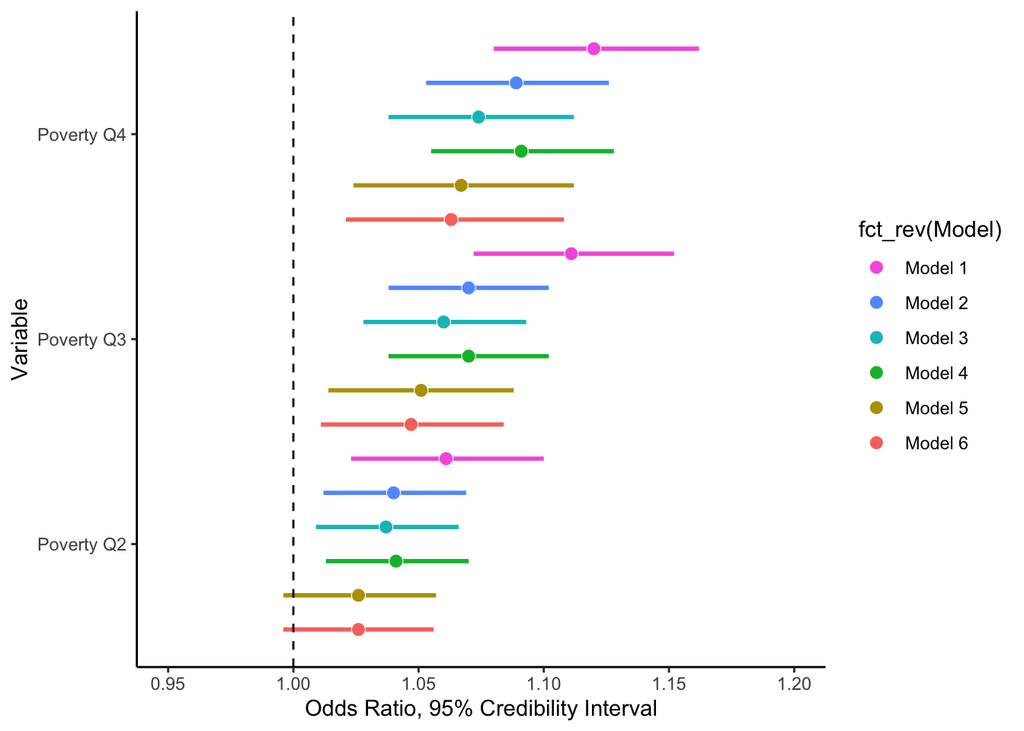

```r
p <- ggplot(data = plot, aes(x = Variable, y = OR, ymin = Lower, ymax = Upper,
                      col = fct_rev(Model), fill = fct_rev(Model), palette = "Spectral")) +
     geom_linerange(linewidth = 1, position = position_dodge(width = 1), show.legend = FALSE) +
     geom_hline(yintercept = 1, lty = 2) +
     geom_point(size = 3, shape = 21, color = "white", stroke = 0.3,
                position = position_dodge(width = 1)) +
     guides(fill = guide_legend(reverse = TRUE)) +
     scale_x_discrete(name = "Variable") +
     scale_y_continuous(name = "Odds Ratio, 95% Credibility Interval", limits = c(0.95, 1.2)) +
     coord_flip () +
     theme_classic()

# ggsave("p.png", scale = 1, dpi = 300)

p
```